# Spatail Data

# Spatail Data

What do you think spatial data looks like? What do you think a spatail data vis looks like? Can you find any exaample online?

- map-able data

How are spatial data represented?

spatial data are specail - while encoding as numbers (double) - these numbers actually have special meaning

spatial vectors (non R-specific)

3 main types

- Point (1, 4) train station locations, wells
- Line (Line string) ((1, 4), (4, 5)) roads
- Polygon ((1, 4), (4, 5), ….) council areas, lakes

# Spatial Data in R

sometimes we just get given dataframes with lat-long colums

another option is to load in shapefiles

```r
library(tidyverse)
```

a feature = a gometry

```r
north_carolina <- st_read(system.file("shape/nc.shp",
                                      package = "sf"))
```

```r
north_carolina %>%
  as.tibble()
```

| AREA | PERIMETER | CNTY_ | CNTY_ID | NAME | FIPS | FIPSNO | CRESS_ID | BIR74 | SID74 | NWBIR74 | BIR79 | SID79 | NWBIR79 | geometry |
| --- | --- | --- | --- | --- | --- | --- | --- | --- | --- | --- | --- | --- | --- | --- |
| 0.114 | 1.442 | 1825 | 1825 | Ashe | 37009 | 37009 | 5 | 1091 | 1 | 10 | 1364 | 0 | 19 |  |
| 0.061 | 1.231 | 1827 | 1827 | Alleghany | 37005 | 37005 | 3 | 487 | 0 | 10 | 542 | 3 | 12 |  |
| 0.143 | 1.630 | 1828 | 1828 | Surry | 37171 | 37171 | 86 | 3188 | 5 | 208 | 3616 | 6 | 260 |  |
| 0.070 | 2.968 | 1831 | 1831 | Currituck | 37053 | 37053 | 27 | 508 | 1 | 123 | 830 | 2 | 145 |  |
| 0.153 | 2.206 | 1832 | 1832 | Northampton | 37131 | 37131 | 66 | 1421 | 9 | 1066 | 1606 | 3 | 1197 |  |
| 0.097 | 1.670 | 1833 | 1833 | Hertford | 37091 | 37091 | 46 | 1452 | 7 | 954 | 1838 | 5 | 1237 |  |
| 0.062 | 1.547 | 1834 | 1834 | Camden | 37029 | 37029 | 15 | 286 | 0 | 115 | 350 | 2 | 139 |  |
| 0.091 | 1.284 | 1835 | 1835 | Gates | 37073 | 37073 | 37 | 420 | 0 | 254 | 594 | 2 | 371 |  |
| 0.118 | 1.421 | 1836 | 1836 | Warren | 37185 | 37185 | 93 | 968 | 4 | 748 | 1190 | 2 | 844 |  |
| 0.124 | 1.428 | 1837 | 1837 | Stokes | 37169 | 37169 | 85 | 1612 | 1 | 160 | 2038 | 5 | 176 |  |

[output cut: 90 more lines]

```r
nc_geo <- st_geometry(north_carolina)
```

```r
nc_geo[[1]]
```

```
MULTIPOLYGON (((-81.47276 36.23436, -81.54084 36.27251, -81.56198 36.27359, -81.63306 36.34069, -81.74107 36.39178, -81.69828 36.47178, -81.7028 36.51934, -81.67 36.58965, -81.3453 36.57286, -81.34754 36.53791, -81.32478 36.51368, -81.31332 36.4807, -81.26624 36.43721, -81.26284 36.40504, -81.24069 …
```

```r
class(north_carolina)
```

```
[1] "sf"         "data.frame"
```

it’s a dataframe with geometries

# Plotting Geometries

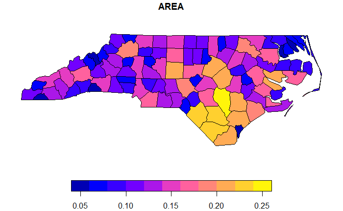

```r
plot(north_carolina["AREA"])
```

`st_as_sf()` - convert non-sf objects (that include geometries) into sf objects

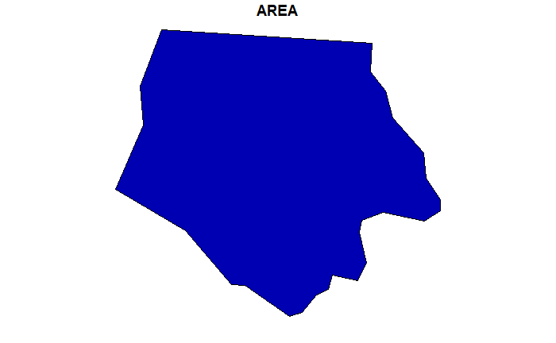

```r
# subset the county
plot(north_carolina[1,1])
```

### Task - 5 mins

Have a look through some of the variables within your north_carolina dataset, and see if you can create a spatial plot using the techniques above.

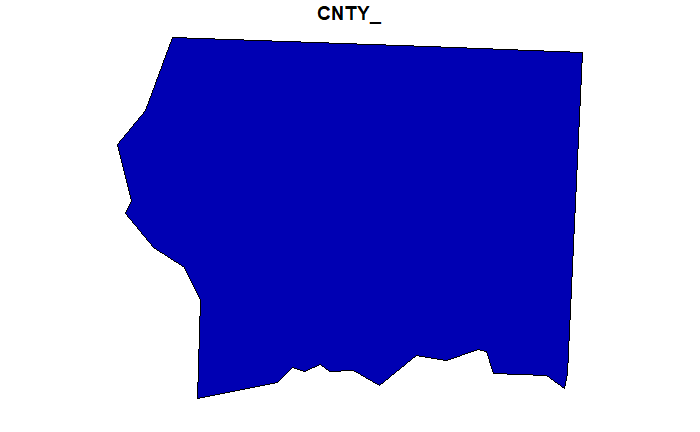

```r
plot(north_carolina[3, 3, 1, 1])
```

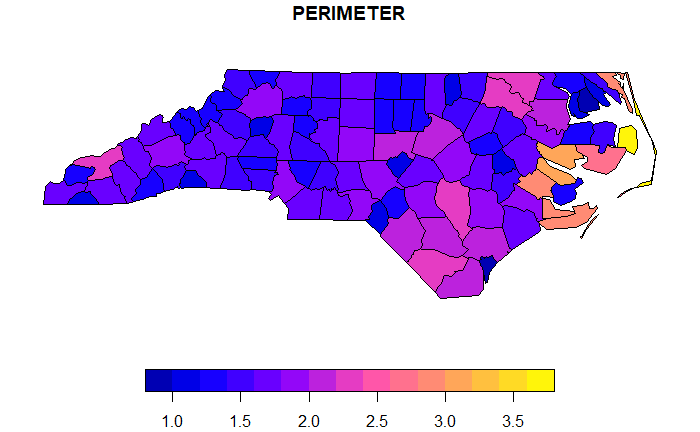

```r
plot(north_carolina["PERIMETER"])
```

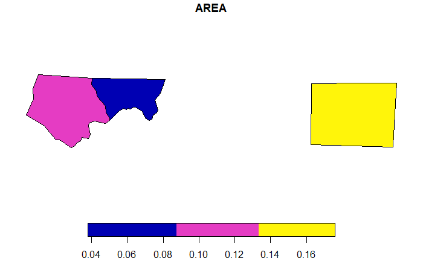

```r
plot(north_carolina[c(1, 2, 12), "AREA"])
```

# ggplot and sf

`geom_sf()`

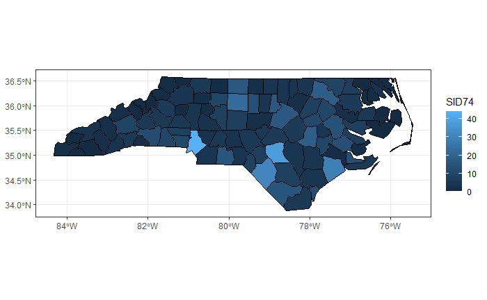

```r
 north_carolina %>%
  ggplot() +
  geom_sf(aes(fill = SID74), colour = "black") +
  theme_bw()
```

### Task : 5 mins

Try your hand at plotting another feature from the north_carolina dataset. What does it tell you?

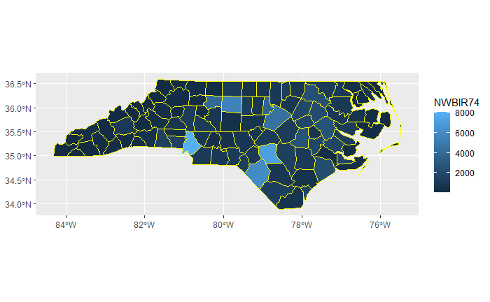

```r
 north_carolina %>%
  ggplot() +
  geom_sf(aes(fill = NWBIR74), colour = "yellow") +
  theme_gray()
```

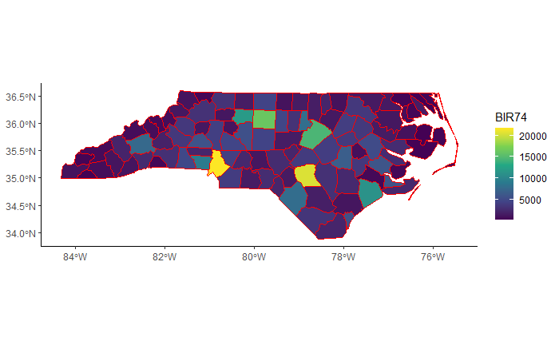

```r
north_carolina %>%
  ggplot() +
  geom_sf(aes(fill = BIR74), colour = "red", size = 0.1) +
  scale_fill_continuous(type = "viridis") +
  theme_classic()
```

```r
library(rgeos)
library(rnaturalearth)
library(rnaturalearthdata)
```

```r
world <- ne_countries(scale = "medium", returnclass = "sf")
class(world)
```

```
[1] "sf"         "data.frame"
```

```r
view(world)
head(world, 1)
```

```
Simple feature collection with 1 feature and 63 fields
Geometry type: MULTIPOLYGON
Dimension:     XY
Bounding box:  xmin: -70.06611 ymin: 12.423 xmax: -69.8957 ymax: 12.61411
CRS:           +proj=longlat +datum=WGS84 +no_defs +ellps=WGS84 +towgs84=0,0,0
  scalerank      featurecla labelrank  sovereignt sov_a3 adm0_dif level    type admin adm0_a3 geou_dif geounit gu_a3
0         3 Admin-0 country         5 Netherlands    NL1        1     2 Country Aruba     ABW        0   Aruba   ABW
  su_dif subunit su_a3 brk_diff  name name_long brk_a3 brk_name brk_group abbrev postal formal_en formal_fr note_adm0
0      0   Aruba   ABW        0 Aruba     Aruba    ABW    Aruba      <NA>  Aruba     AW     Aruba      <NA>     Neth.
  note_brk name_sort name_alt mapcolor7 mapcolor8 mapcolor9 mapcolor13 pop_est gdp_md_est pop_year lastcensus gdp_year
0     <NA>     Aruba     <NA>         4         2         2          9  103065       2258       NA       2010       NA
               economy              income_grp wikipedia fips_10 iso_a2 iso_a3 iso_n3 un_a3 wb_a2 wb_a3 woe_id adm0_a3_is
0 6. Developing region 2. High income: nonOECD        NA    <NA>     AW    ABW    533   533    AW   ABW     NA        ABW
  adm0_a3_us adm0_a3_un adm0_a3_wb     continent region_un subregion                 region_wb name_len long_len
0        ABW         NA         NA North America  Americas Caribbean Latin America & Caribbean        5        5
  abbrev_len tiny homepart                       geometry
0          5    4       NA MULTIPOLYGON (((-69.89912 1...
```

```r
world %>%
  as.tibble() %>%
  head(5)
```

| scalerank | featurecla | labelrank | sovereignt | sov_a3 | adm0_dif | level | type | admin | adm0_a3 | geou_dif | geounit | gu_a3 | su_dif | subunit | su_a3 | brk_diff | name | name_long | brk_a3 | brk_name | brk_group | abbrev | postal | formal_en | formal_fr | note_adm0 | note_brk | name_sort | name_alt | … |
| --- | --- | --- | --- | --- | --- | --- | --- | --- | --- | --- | --- | --- | --- | --- | --- | --- | --- | --- | --- | --- | --- | --- | --- | --- | --- | --- | --- | --- | --- | --- |
| 3 | Admin-0 country | 5 | Netherlands | NL1 | 1 | 2 | Country | Aruba | ABW | 0 | Aruba | ABW | 0 | Aruba | ABW | 0 | Aruba | Aruba | ABW | Aruba | NA | Aruba | AW | Aruba | NA | Neth. | NA | Aruba | NA | … |
| 1 | Admin-0 country | 3 | Afghanistan | AFG | 0 | 2 | Sovereign country | Afghanistan | AFG | 0 | Afghanistan | AFG | 0 | Afghanistan | AFG | 0 | Afghanistan | Afghanistan | AFG | Afghanistan | NA | Afg. | AF | Islamic State of Afghanistan | NA | NA | NA | Afghanistan | NA | … |
| 1 | Admin-0 country | 3 | Angola | AGO | 0 | 2 | Sovereign country | Angola | AGO | 0 | Angola | AGO | 0 | Angola | AGO | 0 | Angola | Angola | AGO | Angola | NA | Ang. | AO | People's Republic of Angola | NA | NA | NA | Angola | NA | … |
| 1 | Admin-0 country | 6 | United Kingdom | GB1 | 1 | 2 | Dependency | Anguilla | AIA | 0 | Anguilla | AIA | 0 | Anguilla | AIA | 0 | Anguilla | Anguilla | AIA | Anguilla | NA | Ang. | AI | NA | NA | U.K. | NA | Anguilla | NA | … |
| 1 | Admin-0 country | 6 | Albania | ALB | 0 | 2 | Sovereign country | Albania | ALB | 0 | Albania | ALB | 0 | Albania | ALB | 0 | Albania | Albania | ALB | Albania | NA | Alb. | AL | Republic of Albania | NA | NA | NA | Albania | NA | … |

okay so we’ve got the data, now we can plot it

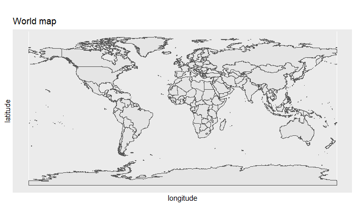

```r
world %>%
  ggplot() +
  geom_sf() +
  labs(x = "longitude", y = "latitude", title = "World map")
```

We can plot actual data now

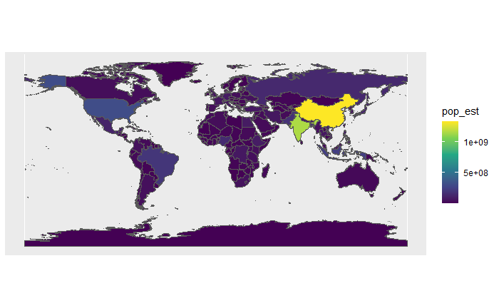

```r
world %>%
  ggplot() +
  geom_sf(aes(fill = pop_est)) +
  scale_fill_viridis_c()
```

### Task - 5 mins

Recap your knowledge from ggplot week, and set your geom_sf aesthetic to be filled with the estimated gdp (gdp_md_est variable). Extra points if you make your map colour blind friendly!

What does your plot tell you? What does it tell you compared to the population?

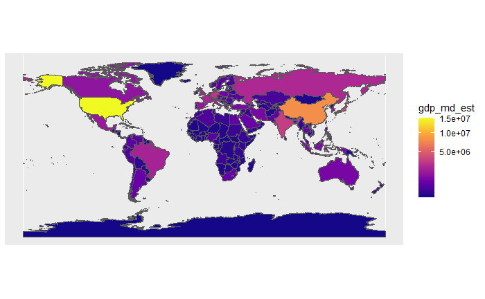

```r
world %>%
  ggplot() +
  geom_sf(aes(fill = gdp_md_est)) +
  scale_fill_viridis_c(option = "plasma", trans = "sqrt")
```

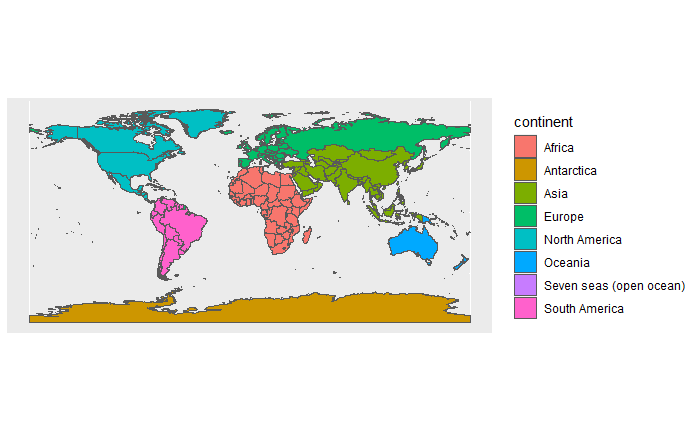

```r
world %>%
  ggplot() +
  geom_sf(aes(fill = continent))
```

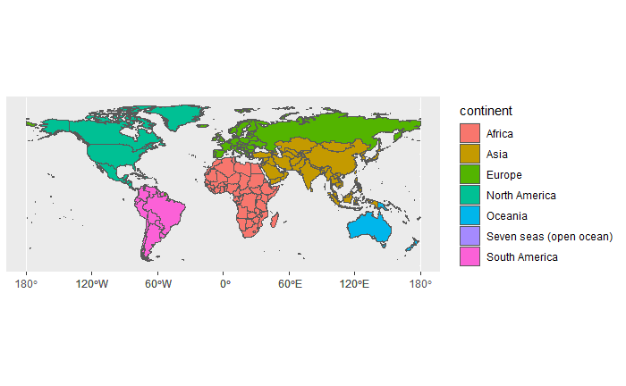

```r
world %>%
  filter(continent != "Antarctica") %>%
  ggplot() +
  geom_sf(aes(fill = continent))
```

# 4.3 Subsetting simple features

What if we only care about one particular country? We can subset the data as we would in tidyverse:

```r
country_italy <- world %>%
  filter(name == "Italy")
```

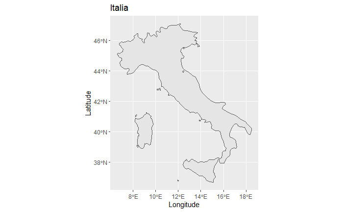

```r
country_italy %>%
  ggplot() +
  geom_sf() +
  labs(x = "Longitude", y = "Latitude", title = "Italia")
```

```r
country_scot <- world %>%
  filter(name == "Scotland")
```

[figure not shown]

```r
country_scot %>%
  ggplot() +
  geom_sf() +
  labs(x = "Longitude", y = "Latitude", title = "Scotland")
```

```r
country_uk <- world %>%
  filter(name == "United Kingdom")
```

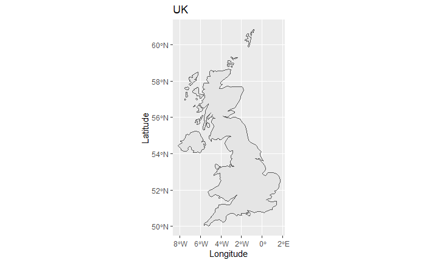

```r
country_uk %>%
  ggplot() +
  geom_sf() +
  labs(x = "Longitude", y = "Latitude", title = "UK")
```

# Zooming in on particular parts of the world

- we can subset our graph by limiting the x and y range using `coord_sf()`
- ggplot

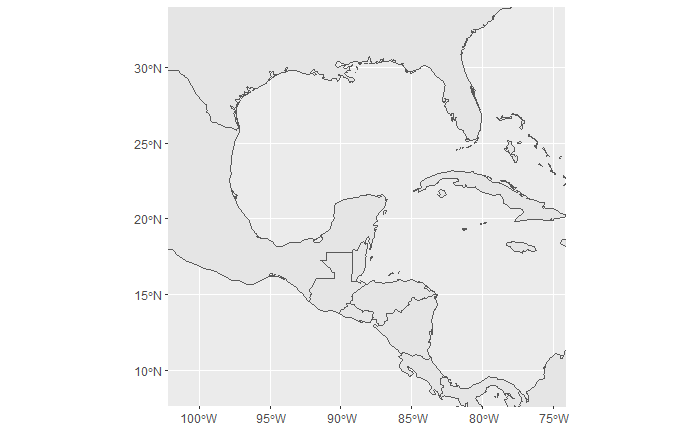

```r
world %>%
  ggplot() +
  geom_sf() +
  coord_sf(xlim = c(-102.15, -74.12), ylim = c(7.65, 33.97), expand = FALSE)
```

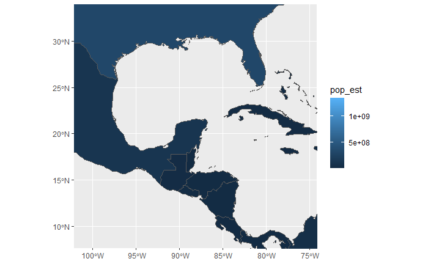

```r
ggplot(data = world) +
    geom_sf(aes(fill = pop_est)) +
    coord_sf(xlim = c(-102.15, -74.12), ylim = c(7.65, 33.97), expand = FALSE)
```

Add informative lables

- we need to tell ggplot where to put the lables
- we need to calculate where we want to put the labels (centre of each feature)
- we need to calculate the centres (centroids)

```r
world %>%
  mutate(centre = st_centroid(st_make_valid(geometry))) %>%
  ds_tibble() %>%
  select(name, centre)
```

```
Error in ds_tibble(.) : could not find function "ds_tibble"
```

```r
world_centre <- world %>%
  mutate(centre = st_centroid(st_make_valid(geometry))) %>%
  mutate(lat = st_coordinates(centre)[,1],
         long = st_coordinates(centre)[,2])
```

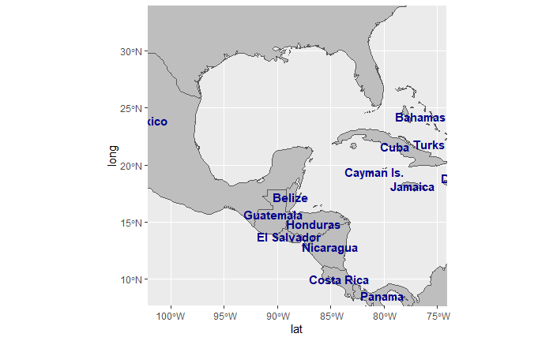

```r
# plot these, along side our zoomed in
ggplot(data = world_centre) +
geom_sf(fill ="grey") +
 geom_text(aes(x = lat , y = long, label = name), color = "darkblue", fontface = "bold", check_overlap = TRUE) +
coord_sf(xlim = c(-102.15, -74.12), ylim = c(7.65, 33.97), expand = FALSE)
```

we can add additionla information using annotate

- add one that says: Gulf of Mexico

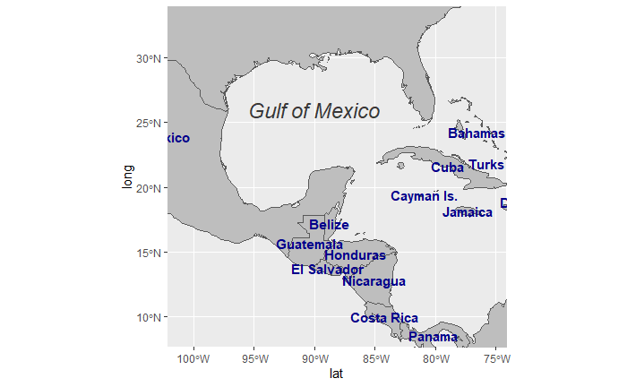

```r
# the annotate function can be used to add a single character string at a specific location, as demonstrated here to add the Gulf of Mexico.
ggplot(data = world_centre) +
geom_sf(fill ="grey") +
 geom_text(aes(x = lat , y = long, label = name), color = "darkblue", fontface = "bold", check_overlap = TRUE) +
annotate(geom = "text", x = -90, y = 26, label = "Gulf of Mexico", fontface = "italic", color = "grey22", size = 6) +
coord_sf(xlim = c(-102.15, -74.12), ylim = c(7.65, 33.97), expand = FALSE)
```

### Task - 10 mins

Have a play around with the plot above, and see what changing parameters does, what using different variables does, what else you can plot, etc

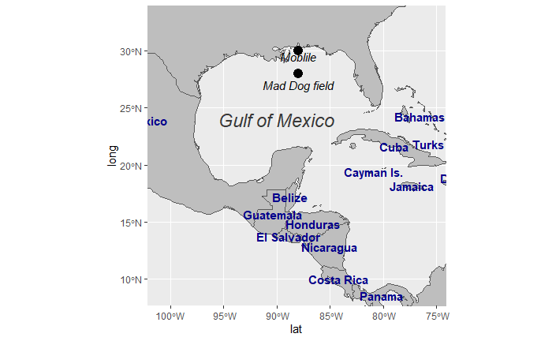

```r
ggplot(data = world_centre) +
geom_sf(fill ="grey") +
 geom_text(aes(x = lat , y = long,
               label = name),
           color = "darkblue",
           fontface = "bold",
           check_overlap = TRUE) +
  annotate(geom = "point", x = -88, y = 28,
           label = "Mad Dog field",
           fontface = "italic",
           color = "black",
           size = 4) +
  annotate(geom = "text", x = -88, y = 27,
           label = "Mad Dog field",
           fontface = "italic",
           color = "black",
           size = 4) +
  annotate(geom = "point", x = -88, y = 30,
           label = "moblile",
           fontface = "italic",
           color = "black",
           size = 4) +
  annotate(geom = "text", x = -88, y = 29.5,
           label = "Moblile",
           fontface = "italic",
           color = "black",
           size = 4) +
  annotate(geom = "text", x = -90, y = 24,
           label = "Gulf of Mexico",
           fontface = "italic",
           color = "grey22",
           size = 6) +
  coord_sf(xlim = c(-102.15, -74.12),
           ylim = c(7.65, 33.97),
           expand = FALSE)
```

projectioon; wgs84 (1984)

####Louise work

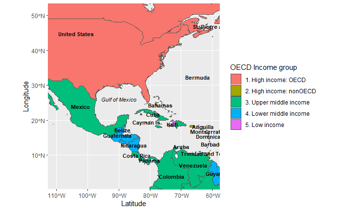

```r
world_centre %>%
  ggplot() +
  geom_sf(aes(fill = income_grp)) +
  geom_text(aes(x = lat, y = long, label = name), colour = "black",
            fontface = "bold", check_overlap = TRUE, size = 3) +
  annotate(geom = "text", x = -90, y = 26, label = "Gulf of Mexico", size = 3,
           fontface = "italic")+
  coord_sf(xlim = c(-110.15, -60.12), ylim = c(2.65, 50.97), expand = TRUE) +
  labs(x = "Latitude",
       y = "Longitude",
       fill = "OECD Income group")
```

#### Ricardo work

```r
world_centre %>%
  ggplot() +
  geom_sf(aes(fill = name), show.legend = F) +
  geom_text(aes(lat, long, label = name), size = 2.5) +
  annotate(geom = "text", x = -90, y = 26, label = "Gulf of Mexico",
           size = 4, fontface = "italic",
           check_overlap = TRUE) +
  coord_sf(xlim = c(-110, -60), ylim = c(8, 35), expand = T) +
  theme_minimal()
```

[output not shown]

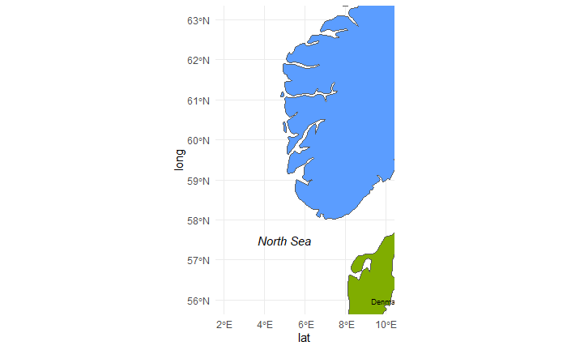

```r
world_centre %>%
  ggplot() +
  geom_sf(aes(fill = name), show.legend = F) +
  geom_text(aes(lat, long, label = name), size = 2.5) +
  annotate(geom = "text", x = 5, y = 57.5, label = "North Sea",
           size = 4, fontface = "italic",
           check_overlap = TRUE) +
  coord_sf(xlim = c(02, 010), ylim = c(56, 63), expand = T) +
  theme_minimal()
```

```r
library(leaflet)
```

```r
leaflet() %>%
  addTiles() %>% #basemap
  addMarkers(lng = 174.768, lat = -36.852, popup = "The birth place of R")
```

[interactive chart not shown]

That was our first leaflet

get some spatial data from the web - turn it into a format R can work with - visualise it using leaflet

```r
library(jsonlite)
```

```r
colarado_data_url <- "https://data.colorado.gov/resource/j5pc-4t32.json?&county=BOULDER"
```

```r
head(readLines(colarado_data_url))
```

```
[1] "[ {"                                                      "  \"station_name\" : \"PECK-PELLA AUGMENTATION RETURN\","
[3] "  \"div\" : \"1\","                                       "  \"location\" : {"
[5] "    \"latitude\" : \"40.160705\","                        "    \"needs_recoding\" : false,"
```

jsonlite package has a lot of functions to help work with json data

json is like a list of lists in R - sometimes we need to recursively sift through to extract the relevant data

```r
water_data_df <- fromJSON(colarado_data_url) %>%
  # remove the nested data frame 'location' column to unnest the latitude and longitudes using 'flatten' from jsonlite
  jsonlite::flatten(recursive = TRUE)
```

```r
water_data_df_clean %>%
  select(-location.needs_recoding) %>%
  mutate(across(starts_with("location"), as.numeric) %>%
  filter(!is.na(location.latitude), !is.na(location.latitude)))
```

| station_name | div | dwr_abbrev | data_source | amount | station_type | wd | date_time | county | variable | station_status | stage | usgs_station_id | flag | location.latitude | location.longitude | http_linkage.url |
| --- | --- | --- | --- | --- | --- | --- | --- | --- | --- | --- | --- | --- | --- | --- | --- | --- |
| PECK-PELLA AUGMENTATION RETURN | 1 | PECRTNCO | Co. Division of Water Resources | 0.00 | Diversion | 5 | 2021-12-14T04:00:00.000 | BOULDER | DISCHRG | Active | NA | NA | NA | 40.16071 | -105.1685 | https://dwr.state.co.us/Tools/Stations/PECRTNCO |
| HIGHLAND DITCH AT LYONS, CO | 1 | HIGHLDCO | Co. Division of Water Resources | 0.00 | Diversion | 5 | 2021-12-14T04:30:00.000 | BOULDER | DISCHRG | Active | -0.07 | NA | NA | 40.21504 | -105.2560 | https://dwr.state.co.us/Tools/Stations/HIGHLDCO |
| BOULDER-LARIMER BYPASS NEAR BERTHOUD | 1 | BOUBYPCO | Co. Division of Water Resources | 2.39 | Diversion | 4 | 2021-12-14T04:15:00.000 | BOULDER | DISCHRG | Active | 0.27 | NA | NA | 40.25873 | -105.1758 | https://dwr.state.co.us/Tools/Stations/BOUBYPCO |
| BOULDER CREEK NEAR ORODELL, CO. | 1 | BOCOROCO | Co. Division of Water Resources | 10.80 | Stream | 6 | 2021-12-14T04:15:00.000 | BOULDER | DISCHRG | Active | 1.76 | 06727000 | Ice | 40.00653 | -105.3305 | https://dwr.state.co.us/Tools/Stations/BOCOROCO |
| PALMERTON DITCH | 1 | PALDITCO | Cooperative Program of CDWR, NCWCD & SVLHWCD | 0.35 | Diversion | 5 | 2021-12-14T04:00:00.000 | BOULDER | DISCHRG | Active | 0.06 | NA | NA | 40.21251 | -105.2518 | https://dwr.state.co.us/Tools/Stations/PALDITCO |
| SWEDE DITCH | 1 | SWEDITCO | Cooperative Program of CDWR, NCWCD & SVLHWCD | 0.00 | Diversion | 5 | 2021-12-14T04:00:00.000 | BOULDER | DISCHRG | Active | NA | NA | NA | 40.21109 | -105.2509 | https://dwr.state.co.us/Tools/Stations/SWEDITCO |
| LITTLE THOMPSON #2 DITCH | 1 | LITTH2CO | Northern Water | 0.00 | Diversion | 4 | 2021-12-14T04:00:00.000 | BOULDER | DISCHRG | Active | 0.00 | ES1900 | NA | 40.25579 | -105.2095 | https://dwr.state.co.us/Tools/Stations/LITTH2CO |
| FOURMILE CREEK AT ORODELL, CO | 1 | FOUOROCO | U.S. Geological Survey | 0.78 | Stream | 6 | 2021-10-13T08:50:00.000 | BOULDER | DISCHRG | Active | NA | 06727500 | NA | 40.01867 | -105.3263 | https://dwr.state.co.us/Tools/Stations/FOUOROCO |
| PANAMA RESERVOIR OUTLET | 1 | PNMOUTCO | Co. Division of Water Resources | 0.80 | Stream | 6 | 2021-12-14T04:00:00.000 | BOULDER | DISCHRG | Active | NA | NA | NA | 40.08758 | -105.0725 | https://dwr.state.co.us/Tools/Stations/PNMOUTCO |
| SMEAD DITCH | 1 | SMEDITCO | Cooperative Program of CDWR, NCWCD & SVLHWCD | 0.32 | Diversion | 5 | 2021-12-14T04:00:00.000 | BOULDER | DISCHRG | Active | 0.15 | NA | NA | 40.21140 | -105.2510 | https://dwr.state.co.us/Tools/Stations/SMEDITCO |

[output cut: 74 more lines]

```r
# turn columns to numeric and remove NA values
water_data_df_clean <- water_data_df %>%
  mutate_at(vars(amount, location.latitude, location.longitude), as.numeric) %>%
  filter(!is.na(location.latitude))

# create leaflet map
leaflet(water_data_df_clean) %>%
  addTiles() %>%
  addCircleMarkers(lng = ~location.longitude,
                   lat = ~location.latitude)
```

[interactive chart not shown]

- incidences of surface water in abd around Boulder Coloardo

```r
leaflet(water_data_df_clean) %>%
  addTiles() %>%
  addCircleMarkers(lng = ~location.longitude,
                   lat = ~location.latitude,
                   radius = ~ sqrt(amount)/100)
```

[interactive chart not shown]

```r
leaflet(water_data_df_clean) %>%
  addTiles() %>%
  addMarkers(lng = ~location.longitude,
                   lat = ~location.latitude)
```

[interactive chart not shown]

we can add clustering options

```r
leaflet(water_data_df_clean) %>%
  addTiles() %>%
  addMarkers(lng = ~location.longitude,
                   lat = ~location.latitude,
             clusterOptions = markerClusterOptions())
```

[interactive chart not shown]

# Leaflet in Shiny

```r
library(leaflet)
library(CodeClanData)
```

```r
leaflet(whisky) %>%
  addTiles() %>%
  addCircleMarkers(lat = ~Longitude, lng = ~Latitude, popup = ~Distillery)
```

[interactive chart not shown]